# (Airline Performance Explanatory Analysis)

## by (Iman Hassan)

## Investigation Overview

> In this investigation, I'm looking for to know the performance of each Airline , the main reasons of Arrival and Departure Delay and what are the top Airpots that has delay minutes.

## Dataset Overview

> The data set contian more than 14 million rows and more than 15 attributes and features that i will investigate on. Some of those features are Year, Month, DayofMonth, UniqueCarrier, DayofWeek, ArrDelay, DepDelay, orgin, Dest,and Cancelled. There is no data that has been take out but there is some additional attribute that added.

## (Distribution of Top 5 Origin Airports)

> ATL: Hartsfield Jackson Atlanta International Airport is the highest airport origin for all the data with more than 800K flights over the two years, followed by ORD: Chicago O'Hare International Airport.

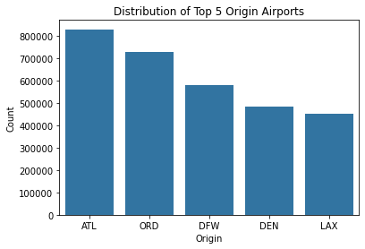

## (Order of the Carrier operator)

> looking through the count of each Airline over the 2 years we can see that the highest airline operator is WN: Southwest Airlines followed by AA: American Airlines but the differance is more than million.

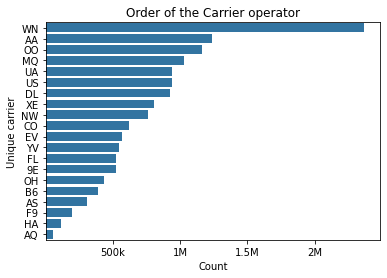

## (Distribution of Arrival Delay)

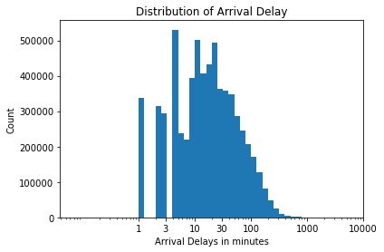

## (Reason of Cancellation)

> Carrier and Weather are the highest reason of delay followed by the National Airspace System (NAS) which contian non-extreme weather conditions, airport operations, heavy traffic volume, air traffic control, etc. note:That is only repersent the cancellated flights which has less number of rows..

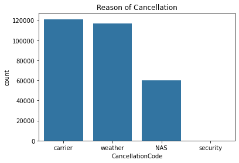

## (Distribution of Carrier Delay)

> Carrier delys takes a bill shape distribuation after taking log tranformation. the 20 minutes are the peak of the data with the hights number of flights.

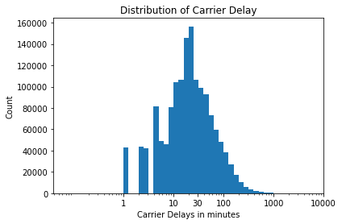

## (Arrival Delay Vs. Departure Delay)

> there is a postive stronge relationship between arrival delay and departure delay. The liner reationship seems to be more stronger when the delay of both attributes are above 500 minutes.

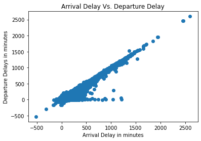

## (Year Vs. Departure Delay)

> As we care about the delay only so the chart represent the Departure delay which is higher than 15 minutes. the 2 years are almost have the same range between 15 and 70 minutes of delay with median is around 40 minutes.

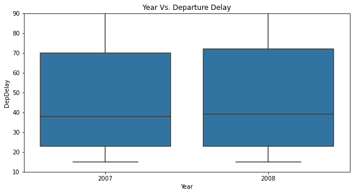

## (Carrier Operators Vs. Carrier Delay)

> 9E: Pinnacle Airlines having the highest range and median of carrier delay that exceed 15 minutes. It median reach above 40 minutes delay.

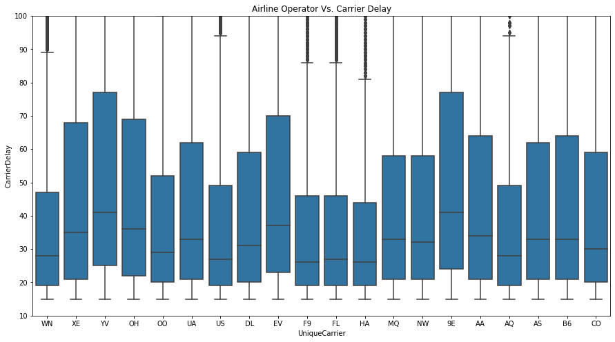

## (Airport Origin Vs. Arrival Delay exceed 15 minutes)

> the Arrival delay vary based on the Flights origin. As the delay of origin of flights affect the Arrival delay we can see that among the top 5 airports origin Chicago airport has the hightest Arrival delay with median around 45 minutes. note: that delay is oly for the flights that exceed 15 minutes already.

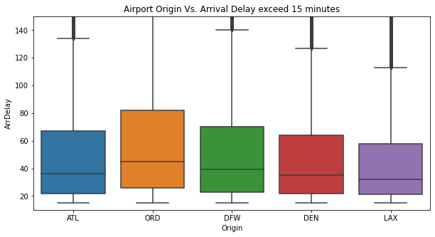

## ( Carrier Delay by Airline operator and year)

> In 2008 the Carrier Delay minutes reach more than 2007. That indicate that delay within the control of the air carrier. In addition, we can see that HA: Hawaiian Airlines that has the highest minutes of delay within their control reach to 33 minutes followed by YV: Mesa Airlines and then EV: Atlantic Southeast Airlines

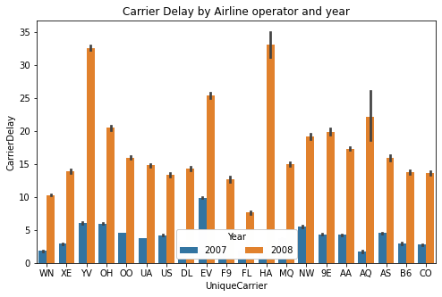

## ( Carrier Delay by Airline operator and Month)

> As 2008 has the highest carrier delay, Hawaiian Airlines has the highest delay in 2008 specially at Feb, March, Sep, and Nov. in addition, the months has lower range but higher median compered to YV: Mesa Airlines that has high range at all months. August is the highest month of carrier delay caused by YV: Mesa Airlines. Jan, Aug, and Sep are the highest in EV:Atlantic Southeast Airlines. AQ: Aloha Airlines has delays only in Jan and Feb but with high median.

```
(-15.0, 50.0)
```

[figure not shown]

## ( Late Aircraft Delay by Origin Airport and Day of the week)

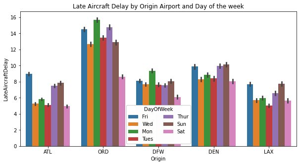